# Fire

Xinlu Jiang

2026-04-13

```r
library(car)
library(lmtest)
library(skedastic)
library(sandwich)
```

## Introduction to “Fire”

This data set contains measurements on 270 forest fires in the northeast region of Portugal.

```r
df = read.table("fire.txt", header = TRUE)
summary(df)
```

```
##        X               Y            month               day
##  Min.   :1.000   Min.   :2.000   Length:270         Length:270
##  1st Qu.:3.000   1st Qu.:4.000   Class :character   Class :character
##  Median :5.000   Median :4.000   Mode  :character   Mode  :character
##  Mean   :4.807   Mean   :4.367
##  3rd Qu.:7.000   3rd Qu.:5.000
##  Max.   :9.000   Max.   :9.000
##       FFMC            DMC              DC             ISI
##  Min.   :63.50   Min.   :  3.2   Min.   : 15.3   Min.   : 0.800
##  1st Qu.:90.33   1st Qu.: 82.9   1st Qu.:486.5   1st Qu.: 6.800
##  Median :91.70   Median :111.7   Median :665.6   Median : 8.400
##  Mean   :91.03   Mean   :114.7   Mean   :570.9   Mean   : 9.177
##  3rd Qu.:92.97   3rd Qu.:141.3   3rd Qu.:721.3   3rd Qu.:11.375
##  Max.   :96.20   Max.   :291.3   Max.   :860.6   Max.   :22.700
##       temp             RH             wind            area
##  Min.   : 2.20   Min.   :15.00   Min.   :0.400   Min.   :   0.09
##  1st Qu.:16.12   1st Qu.:33.00   1st Qu.:2.700   1st Qu.:   2.14
##  Median :20.10   Median :41.00   Median :4.000   Median :   6.37
##  Mean   :19.31   Mean   :43.73   Mean   :4.113   Mean   :  24.60
##  3rd Qu.:23.40   3rd Qu.:53.00   3rd Qu.:4.900   3rd Qu.:  15.42
##  Max.   :33.30   Max.   :96.00   Max.   :9.400   Max.   :1090.84
```

Our response variable is `area`, by our first eye, we noticed that it has a median of 6.37, a mean of 24.6, while the 3rd qu of 15.42, indicating that it does not follow normal distribution for sure and we might transform it into log form in the future.

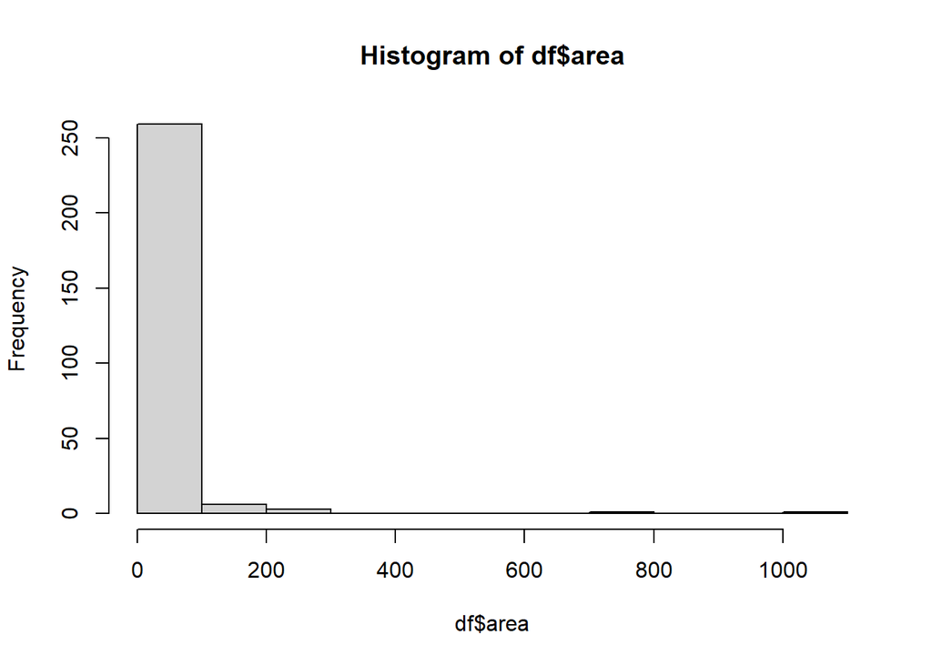

```r
hist(df$area)
```

From our observation of the plot, we are sure that the area probably needs a log transformation. And because it is strictly larger than 0, we can just use `log(area)` instead of `log(area+1)`, which is what we learned on class.

Quantitative covariates includes `FFMC`, `DMC`, `DC`, `ISI`, `temp`, `RH`, `wind`, and location information `X` and `Y`. While the rest, `month` and `day` are qualitative variables that will be used later for fixed/random effects.

### Exploratory Simple Linear Regressions

This part is not required in guidance, yet we find it might be useful as we goes further.

```r
df$log_area = log(df$area)
```

```r
quant_vars = c("X", "Y", "FFMC", "DMC", "DC", "ISI", "temp", "RH", "wind")

uni_models = lapply(quant_vars, function(v) {
  lm(as.formula(paste("log_area ~", v)), data = df)
})

names(uni_models) = quant_vars
```

```r
uni_results = data.frame(
  variable = quant_vars,
  coefficient = sapply(uni_models, function(m) coef(m)[2]),
  p_value = sapply(uni_models, function(m) summary(m)$coefficients[2, 4]),
  r_squared = sapply(uni_models, function(m) summary(m)$r.squared),
  adj_r_squared = sapply(uni_models, function(m) summary(m)$adj.r.squared)
)

uni_results
```

```
##           variable   coefficient    p_value    r_squared adj_r_squared
## X.X              X  0.0127039481 0.74564140 0.0003933053 -0.0033365704
## Y.Y              Y -0.0152818408 0.84800004 0.0001373276 -0.0035935033
## FFMC.FFMC     FFMC -0.0187011559 0.45720384 0.0020641476 -0.0016594936
## DMC.DMC        DMC  0.0007286231 0.62953058 0.0008695186 -0.0028585802
## DC.DC           DC -0.0001929843 0.63438317 0.0008451125 -0.0028830774
## ISI.ISI        ISI -0.0405861424 0.07048861 0.0121557702  0.0084697843
## temp.temp     temp -0.0085240643 0.57244347 0.0011903585 -0.0025365431
## RH.RH           RH -0.0050299974 0.41616044 0.0024684661 -0.0012536665
## wind.wind     wind  0.0442727685 0.37105536 0.0029866539 -0.0007335452
```

From the chart, we find that none of the covariates on its own is statistically significant (alpha=0.05). Most predictors have extremely small $R^2$ values, indicating that each variable alone explains almost none of the variation in burned area. The only variable close to marginal significance is `ISI`, with a p-value around 0.0705, but it is still not significant. And `ISI` itself is actually a combination of `wind` and other indicators.

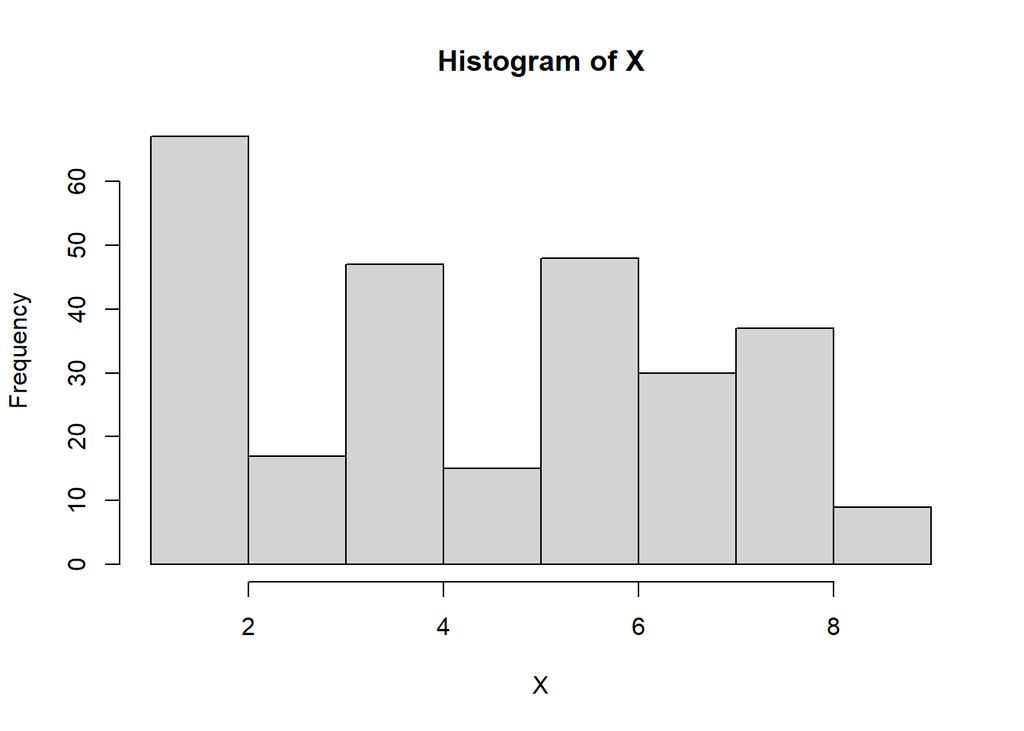

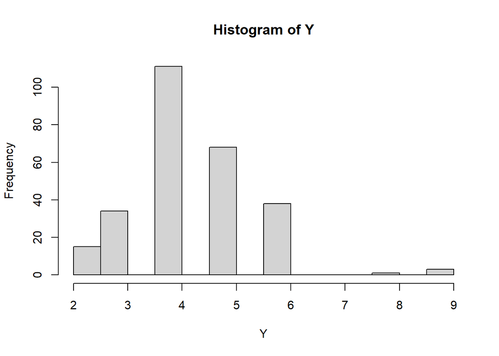

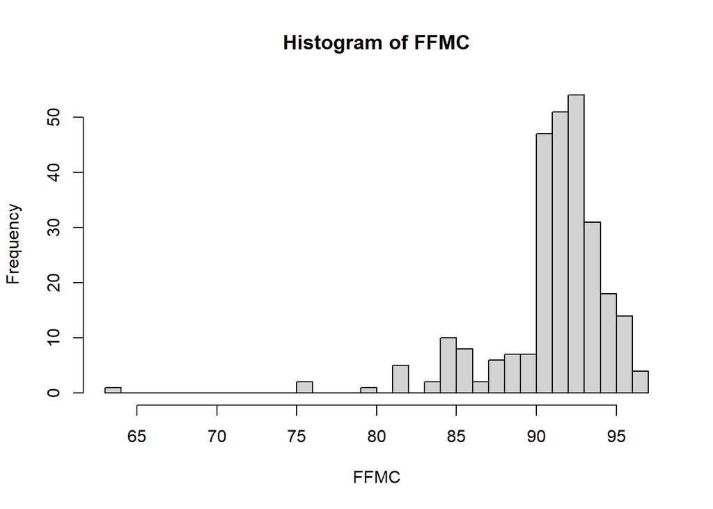

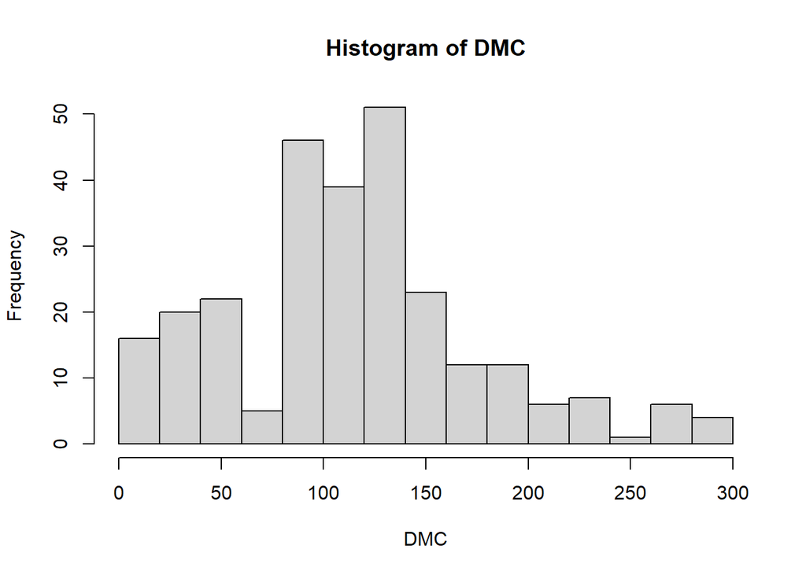

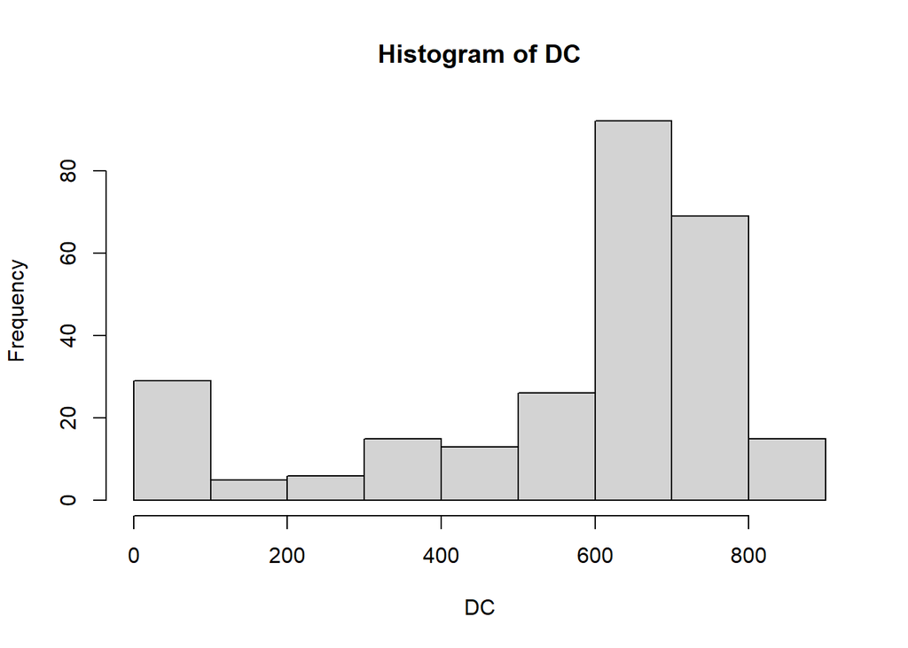

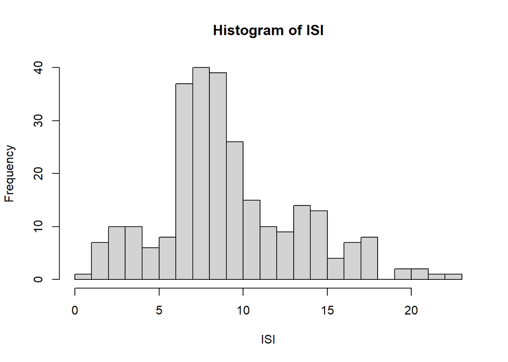

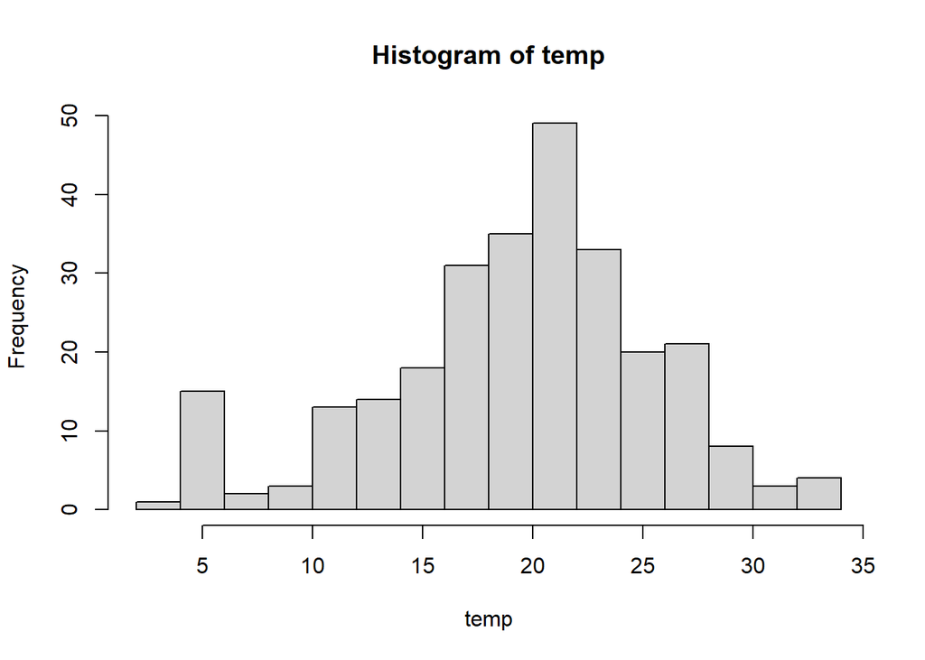

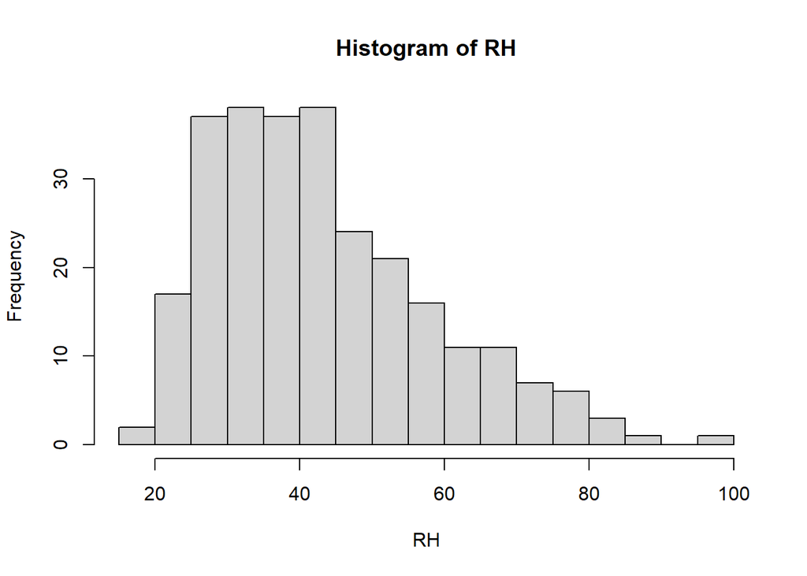

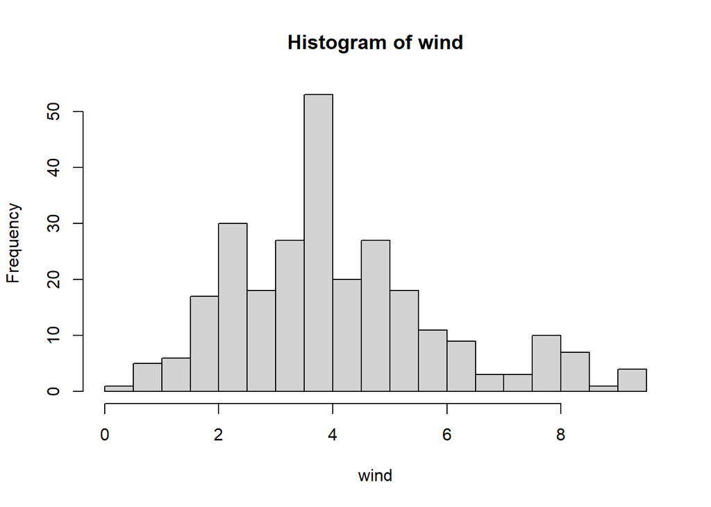

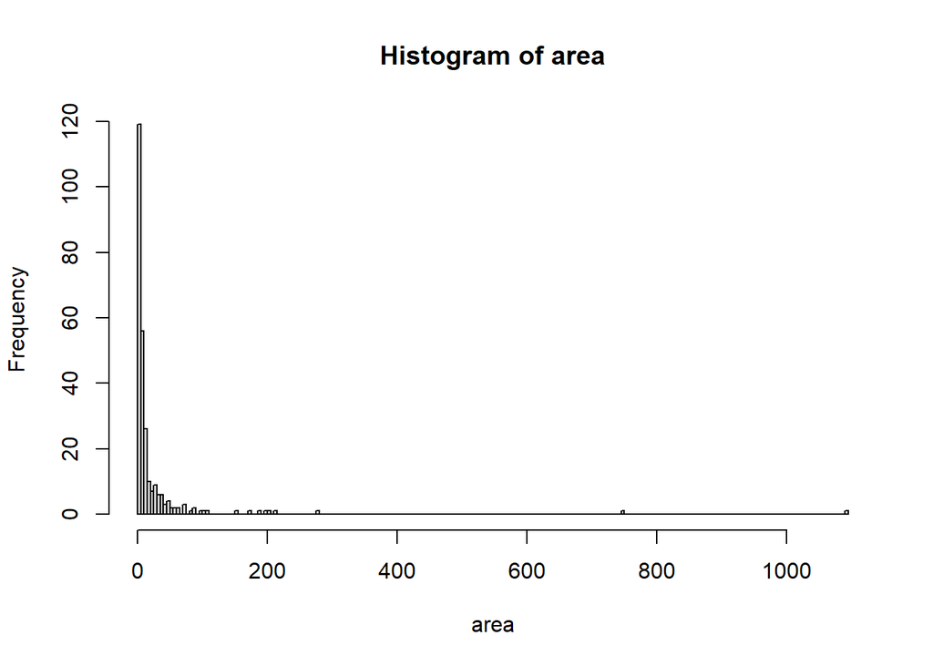

```r
quant_vars = c("X", "Y", "FFMC", "DMC", "DC", "ISI",
               "temp", "RH", "wind", "area")

for (var in quant_vars) {
  hist(df[[var]],
       breaks = "FD",
       main = paste("Histogram of", var),
       xlab = var)
}
```

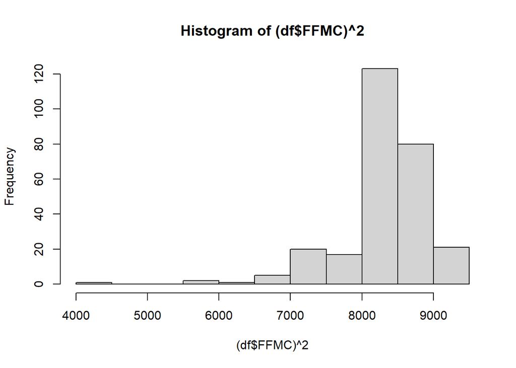

```r
hist((df$FFMC)**2)
```

### Categorical Exploratory Analysis

We also examine the categorical variables `month` and `day`. Instead of immediately fitting a regression model with dummy variables, we first calculate the group-level sample size and average burned area. This helps us understand whether certain months or weekdays are associated with larger observed fire areas.

```r
# to get the right sequence
df$month = factor(
  df$month,
  levels = c("jan", "feb", "mar", "apr", "may", "jun",
             "jul", "aug", "sep", "oct", "nov", "dec")
)

df$day = factor(
  df$day,
  levels = c("mon", "tue", "wed", "thu", "fri", "sat", "sun")
)
```

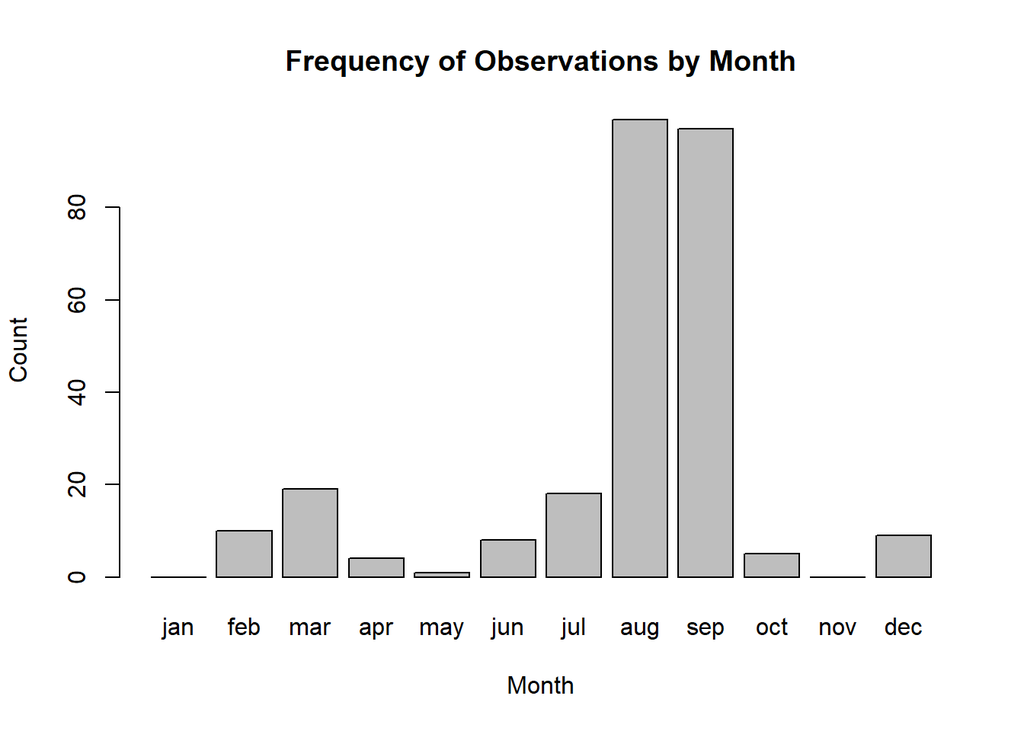

```r
month_counts = table(df$month)

barplot(
  month_counts,
  main = "Frequency of Observations by Month",
  xlab = "Month",
  ylab = "Count"
)
```

From this plot, we can see that Auguest and September is the peak season of forest fire, which aligns to our guess.

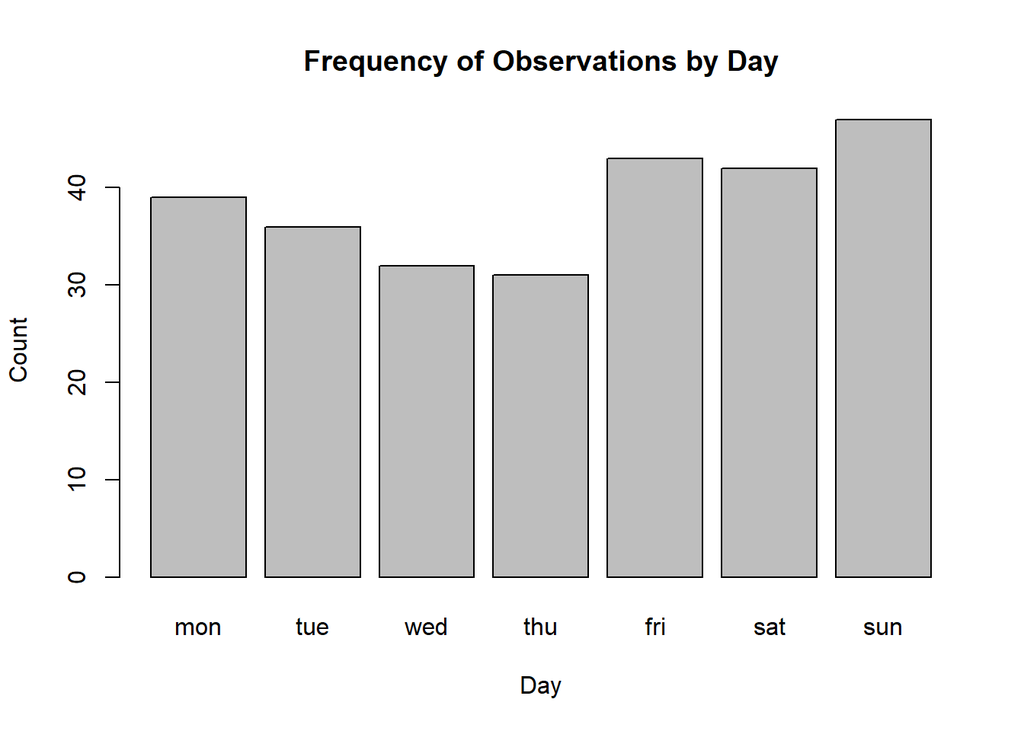

```r
day_counts = table(df$day)

barplot(
  day_counts,
  main = "Frequency of Observations by Day",
  xlab = "Day",
  ylab = "Count"
)
```

Though might not be significant, we can see that weekends, including Friday have a higher chance of fire. We guess that this might be related to human activities, as tourist might be a significant reason of forest fire.

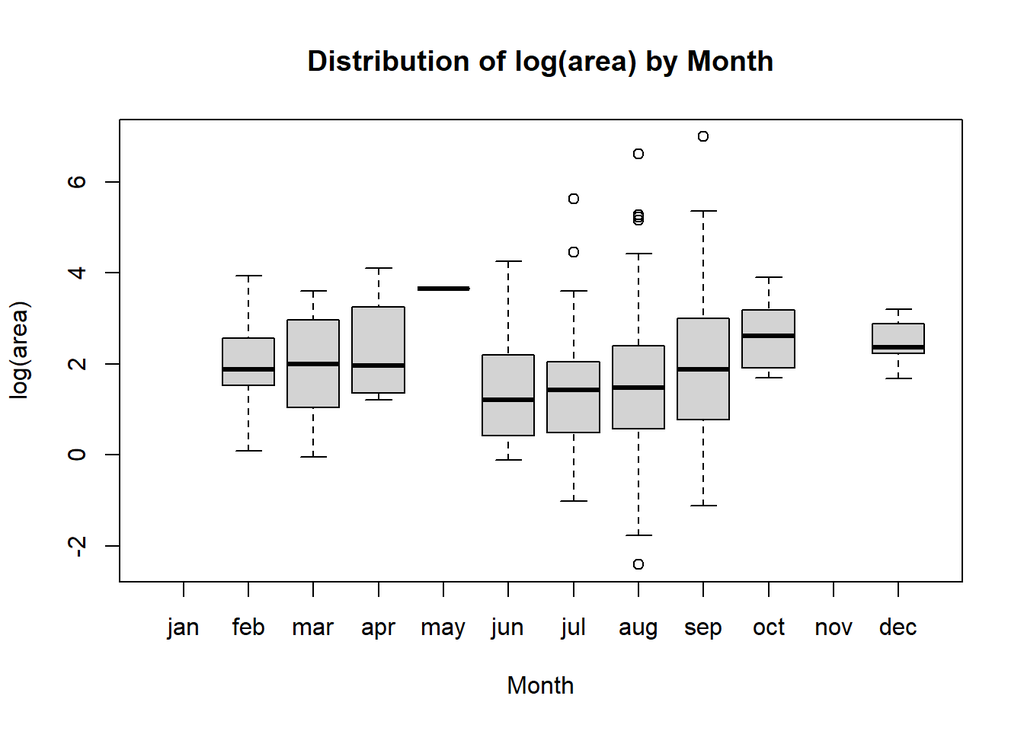

```r
boxplot(
  log_area ~ month,
  data = df,
  xlab = "Month",
  ylab = "log(area)",
  main = "Distribution of log(area) by Month"
)
```

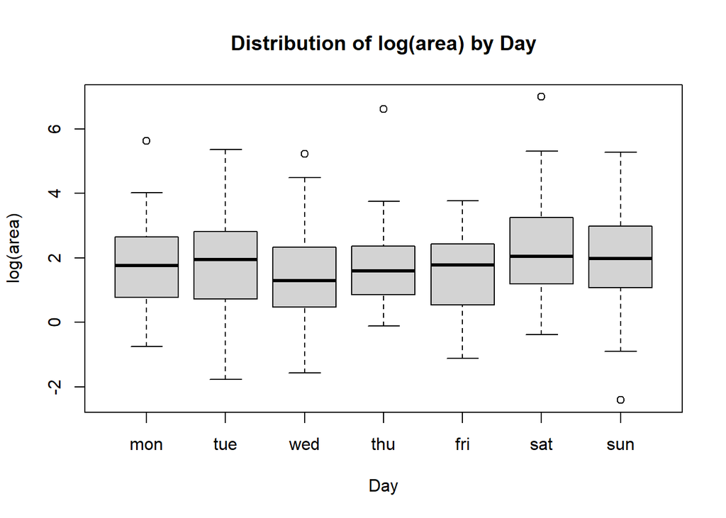

```r
boxplot(
  log_area ~ day,
  data = df,
  xlab = "Day",
  ylab = "log(area)",
  main = "Distribution of log(area) by Day"
)
```

Different from our observation of frequence, the distribution of area by month seems to be quite average. But we can see some trends that weekends seem to have larger, fire area than weekdays.

## Basic Model

### OLS and tests

```r
# We preserve only quantitative covariates at this stage

df_quant = subset(df, select = -c(month, day, log_area)) # we cannot use transformation here

ols_model = lm(area ~ ., data = df_quant)
summary(ols_model)
```

```
##
## Call:
## lm(formula = area ~ ., data = df_quant)
##
## Residuals:
##     Min      1Q  Median      3Q     Max
##  -72.60  -26.21  -12.28    1.12 1046.15
##
## Coefficients:
##              Estimate Std. Error t value Pr(>|t|)
## (Intercept) -43.41569  207.18386  -0.210    0.834
## X             3.17687    2.60343   1.220    0.223
## Y            -0.65104    5.27495  -0.123    0.902
## FFMC          0.58618    2.33019   0.252    0.802
## DMC           0.15223    0.13098   1.162    0.246
## DC           -0.01254    0.03244  -0.387    0.699
## ISI          -1.97004    1.95091  -1.010    0.314
## temp          1.15236    1.40136   0.822    0.412
## RH           -0.51706    0.44890  -1.152    0.250
## wind          2.51915    3.15305   0.799    0.425
##
## Residual standard error: 86.49 on 260 degrees of freedom
## Multiple R-squared:  0.03365,    Adjusted R-squared:  0.0001997
## F-statistic: 1.006 on 9 and 260 DF,  p-value: 0.4355
```

We notice that none of the covariates is statistically significant at the 5% level at this stage, and the adjusted $R^2$ is very low.

```r
constraints <- c("50*DC + 10*RH = 3",
                 "6*ISI + 12*temp = 3")
f_linear_constrain_test <- linearHypothesis(ols_model, constraints, test = "F")
print(f_linear_constrain_test)
```

```
##
## Linear hypothesis test:
## 50 DC  + 10 RH = 3
## 6 ISI  + 12 temp = 3
##
## Model 1: restricted model
## Model 2: area ~ X + Y + FFMC + DMC + DC + ISI + temp + RH + wind
##
##   Res.Df     RSS Df Sum of Sq     F Pr(>F)
## 1    262 1973393
## 2    260 1945070  2     28323 1.893 0.1527
```

```r
wald_linear_constrain_test <- linearHypothesis(ols_model, constraints, test = "Chisq")
print(wald_linear_constrain_test)
```

```
##
## Linear hypothesis test:
## 50 DC  + 10 RH = 3
## 6 ISI  + 12 temp = 3
##
## Model 1: restricted model
## Model 2: area ~ X + Y + FFMC + DMC + DC + ISI + temp + RH + wind
##
##   Res.Df     RSS Df Sum of Sq Chisq Pr(>Chisq)
## 1    262 1973393
## 2    260 1945070  2     28323 3.786     0.1506
```

The exact F test gives a p-value of 0.1527, and the asymptotic Wald test gives a p-value of 0.1506. Both tests lead to the same conclusion: we fail to reject the null hypothesis at the 5% significance level. In other words, the data do not provide sufficient evidence against the two proposed linear constraints.

The chi-square statistic is approximately twice the F statistic because the Wald statistic uses the number of restrictions as the scaling factor. In this case, there are $q = 2$ restrictions, so $3.786 \approx 2 \times 1.893$. The small difference in p-values comes from the fact that the exact F test uses an $F_{2,260}$ reference distribution, while the Wald test uses an asymptotic $\chi^2_2$ reference distribution.

The score test and likelihood ratio test are also commonly used asymptotic tests for model restrictions. Conceptually, the Wald test evaluates how far the unrestricted estimates are from satisfying the null constraints, while the score test evaluates the slope of the likelihood at the restricted estimate. The likelihood ratio test compares the fit of the unrestricted and restricted models directly.

## Heteroscedasticity

OLS standard errors rely on the homoscedasticity assumption. Therefore, we first examine the residual-versus-fitted plot and then use formal heteroscedasticity tests to verify the visual evidence.

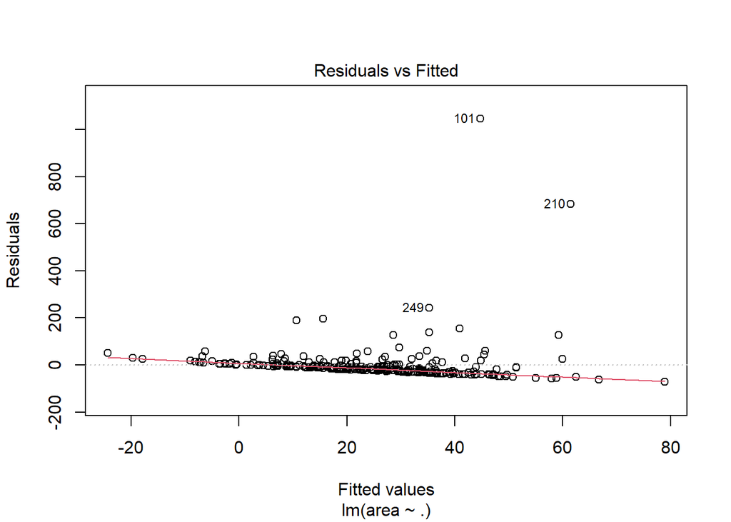

```r
plot(ols_model, which = 1)
```

The residual-versus-fitted plot shows that the basic OLS model with the original response variable `area` is not ideal. Most residuals are concentrated near zero, while a few observations have extremely large positive residuals. In addition, the fitted values include negative values, which is not reasonable for burned area because `area` is nonnegative by definition. So we would like to take a look of transformed model first.

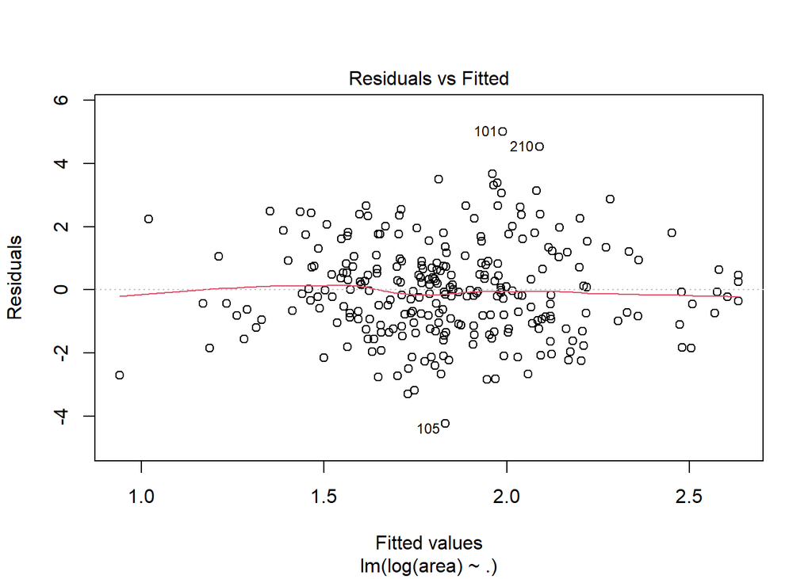

```r
trans_model = lm(log(area)~ ., df_quant)
plot(trans_model, which = 1)
```

```r
bptest(ols_model)
```

```
##
##  studentized Breusch-Pagan test
##
## data:  ols_model
## BP = 5.4, df = 9, p-value = 0.7981
```

```r
bptest(trans_model)
```

```
##
##  studentized Breusch-Pagan test
##
## data:  trans_model
## BP = 14.392, df = 9, p-value = 0.1091
```

We then apply the studentized Breusch-Pagan test to both the original OLS model and the transformed model.

For the original model, the p-value is 0.7981, so we fail to reject the null hypothesis of homoscedasticity. For the transformed model, the p-value is 0.1091, which is still larger than 0.05. Therefore, we also fail to reject the null hypothesis of homoscedasticity for the transformed model.

In conclusion, the Breusch-Pagan test does not provide significant evidence of heteroscedasticity in either model. Therefore, there is no strong statistical evidence that heteroscedasticity is the main issue in this stage. However, the residual plots still show outliers and a less satisfactory residual pattern for the original response model, so we continue to report robust standard errors as a sensitivity check.

### Robust Standard Errors

```r
se_ols <- sqrt(diag(vcov(ols_model)))
se_hc3 <- sqrt(diag(vcovHC(ols_model, type = "HC3")))

compare_se <- data.frame(
  Variable = names(se_ols),
  OLS_SE = se_ols,
  HC3_SE = se_hc3
  )

print(compare_se)
```

```
##                Variable       OLS_SE     HC3_SE
## (Intercept) (Intercept) 207.18385621 87.9218824
## X                     X   2.60342581  1.9016989
## Y                     Y   5.27494704  3.6134407
## FFMC               FFMC   2.33018603  0.9959919
## DMC                 DMC   0.13098417  0.1325100
## DC                   DC   0.03244467  0.0172751
## ISI                 ISI   1.95090751  1.3796752
## temp               temp   1.40136388  1.0014072
## RH                   RH   0.44890020  0.3688818
## wind               wind   3.15305006  1.9740751
```

In this model, the HC3 robust standard errors are smaller than the conventional OLS standard errors for most coefficients.

```r
robust_t_test <- coeftest(ols_model, vcov = vcovHC(ols_model, type = "HC3"))
print(robust_t_test)
```

```
##
## t test of coefficients:
##
##               Estimate Std. Error t value Pr(>|t|)
## (Intercept) -43.415688  87.921882 -0.4938  0.62187
## X             3.176868   1.901699  1.6705  0.09602 .
## Y            -0.651038   3.613441 -0.1802  0.85716
## FFMC          0.586179   0.995992  0.5885  0.55668
## DMC           0.152229   0.132510  1.1488  0.25169
## DC           -0.012543   0.017275 -0.7261  0.46843
## ISI          -1.970044   1.379675 -1.4279  0.15452
## temp          1.152358   1.001407  1.1507  0.25090
## RH           -0.517056   0.368882 -1.4017  0.16220
## wind          2.519146   1.974075  1.2761  0.20305
## ---
## Signif. codes:  0 '***' 0.001 '**' 0.01 '*' 0.05 '.' 0.1 ' ' 1
```

```r
summary(ols_model)
```

```
##
## Call:
## lm(formula = area ~ ., data = df_quant)
##
## Residuals:
##     Min      1Q  Median      3Q     Max
##  -72.60  -26.21  -12.28    1.12 1046.15
##
## Coefficients:
##              Estimate Std. Error t value Pr(>|t|)
## (Intercept) -43.41569  207.18386  -0.210    0.834
## X             3.17687    2.60343   1.220    0.223
## Y            -0.65104    5.27495  -0.123    0.902
## FFMC          0.58618    2.33019   0.252    0.802
## DMC           0.15223    0.13098   1.162    0.246
## DC           -0.01254    0.03244  -0.387    0.699
## ISI          -1.97004    1.95091  -1.010    0.314
## temp          1.15236    1.40136   0.822    0.412
## RH           -0.51706    0.44890  -1.152    0.250
## wind          2.51915    3.15305   0.799    0.425
##
## Residual standard error: 86.49 on 260 degrees of freedom
## Multiple R-squared:  0.03365,    Adjusted R-squared:  0.0001997
## F-statistic: 1.006 on 9 and 260 DF,  p-value: 0.4355
```

The robust t test shows a even better result, though none of the covariates are statistical significant.

```r
robust_ci <- coefci(ols_model, vcov = vcovHC(ols_model, type = "HC3"), level = 0.95)
print("---hc3 vcov---")
```

```
## [1] "---hc3 vcov---"
```

```r
print(robust_ci)
```

```
##                     2.5 %       97.5 %
## (Intercept) -216.54530488 129.71392822
## X             -0.56782387   6.92156074
## Y             -7.76637263   6.46429654
## FFMC          -1.37505828   2.54741676
## DMC           -0.10870043   0.41315856
## DC            -0.04656036   0.02147348
## ISI           -4.68680360   0.74671617
## temp          -0.81954254   3.12425952
## RH            -1.24343206   0.20932035
## wind          -1.36806481   6.40635620
```

```r
ols_ci <- confint(ols_model, level = 0.95)
print("---ols(hc0) vcov---")
```

```
## [1] "---ols(hc0) vcov---"
```

```r
print(ols_ci)
```

```
##                     2.5 %       97.5 %
## (Intercept) -451.38763579 364.55625914
## X             -1.94961543   8.30335231
## Y            -11.03809453   9.73601844
## FFMC          -4.00225998   5.17461845
## DMC           -0.10569580   0.41015392
## DC            -0.07643121   0.05134432
## ISI           -5.81163422   1.87154679
## temp          -1.60710917   3.91182615
## RH            -1.40099872   0.36688700
## wind          -3.68961978   8.72791117
```

Similarly, the 95% robust CIs are smaller than the CIs from OLS.

### Iteratively Reweighted Least Squares

```r
# IRLS with residual variance modeled as a function of temp

irls_model = ols_model
residuals_irls = irls_model$residuals

w = rep(1, nrow(df_quant))
err = Inf
tol = 1e-10
niter = 0
maxiter = 1e3

while (err > tol & niter < maxiter)
{

  aux = lm(log(residuals_irls^2) ~ log(temp), df_quant)
  err = sum(abs(w - exp(-aux$fitted.values))) / sum(w)
  w = exp(-aux$fitted.values)
  WLS = lm(area ~ ., df_quant, weights = w)
  residuals_irls = WLS$residuals
  niter = niter + 1

}

summary(aux)
```

```
##
## Call:
## lm(formula = log(residuals_irls^2) ~ log(temp), data = df_quant)
##
## Residuals:
##     Min      1Q  Median      3Q     Max
## -7.3370 -0.6521 -0.0110  0.6635  7.5334
##
## Coefficients:
##             Estimate Std. Error t value Pr(>|t|)
## (Intercept)  -1.9338     0.6795  -2.846  0.00477 **
## log(temp)     2.5866     0.2328  11.112  < 2e-16 ***
## ---
## Signif. codes:  0 '***' 0.001 '**' 0.01 '*' 0.05 '.' 0.1 ' ' 1
##
## Residual standard error: 1.66 on 268 degrees of freedom
## Multiple R-squared:  0.3154, Adjusted R-squared:  0.3129
## F-statistic: 123.5 on 1 and 268 DF,  p-value: < 2.2e-16
```

```r
summary(WLS)
```

```
##
## Call:
## lm(formula = area ~ ., data = df_quant, weights = w)
##
## Weighted Residuals:
##    Min     1Q Median     3Q    Max
## -2.518 -1.180 -0.857 -0.307 43.238
##
## Coefficients:
##              Estimate Std. Error t value Pr(>|t|)
## (Intercept) 27.372257  88.218400   0.310    0.757
## X            1.145422   1.435768   0.798    0.426
## Y           -0.278324   2.122782  -0.131    0.896
## FFMC        -0.124634   1.017117  -0.123    0.903
## DMC          0.073378   0.082087   0.894    0.372
## DC          -0.002094   0.016917  -0.124    0.902
## ISI          0.458689   0.990276   0.463    0.644
## temp         0.131078   0.563258   0.233    0.816
## RH          -0.247342   0.182666  -1.354    0.177
## wind        -0.149247   1.238758  -0.120    0.904
##
## Residual standard error: 3.723 on 260 degrees of freedom
## Multiple R-squared:  0.04359,    Adjusted R-squared:  0.01049
## F-statistic: 1.317 on 9 and 260 DF,  p-value: 0.2282
```

```r
gamma_hat = coef(aux)

alpha_0_hat = exp(gamma_hat[1])
alpha_1_hat = gamma_hat[2]

alpha_0_hat
```

```
## (Intercept)
##   0.1445908
```

```r
alpha_1_hat
```

```
## log(temp)
##  2.586635
```

```r
cat(
  paste0(
    "Estimated residual variance equation: sigma_i^2 = ",
    round(alpha_0_hat, 4),
    " * temp_i^",
    round(alpha_1_hat, 4)
  )
)
```

```
## Estimated residual variance equation: sigma_i^2 = 0.1446 * temp_i^2.5866
```

```r
ols_summary = summary(ols_model)
irls_summary = summary(irls_model)

compare_ols_irls = data.frame(
  Variable = names(coef(ols_model)),
  OLS_Estimate = coef(ols_model),
  OLS_SE = ols_summary$coefficients[, "Std. Error"],
  OLS_t = ols_summary$coefficients[, "t value"],
  OLS_p_value = ols_summary$coefficients[, "Pr(>|t|)"],
  IRLS_Estimate = coef(irls_model),
  IRLS_SE = irls_summary$coefficients[, "Std. Error"],
  IRLS_t = irls_summary$coefficients[, "t value"],
  IRLS_p_value = irls_summary$coefficients[, "Pr(>|t|)"]
)

print(compare_ols_irls)
```

```
##                Variable OLS_Estimate       OLS_SE      OLS_t OLS_p_value
## (Intercept) (Intercept) -43.41568833 207.18385621 -0.2095515   0.8341818
## X                     X   3.17686844   2.60342581  1.2202646   0.2234702
## Y                     Y  -0.65103804   5.27494704 -0.1234208   0.9018693
## FFMC               FFMC   0.58617924   2.33018603  0.2515590   0.8015807
## DMC                 DMC   0.15222906   0.13098417  1.1621943   0.2462222
## DC                   DC  -0.01254344   0.03244467 -0.3866103   0.6993609
## ISI                 ISI  -1.97004371   1.95090751 -1.0098089   0.3135257
## temp               temp   1.15235849   1.40136388  0.8223121   0.4116528
## RH                   RH  -0.51705586   0.44890020 -1.1518281   0.2504498
## wind               wind   2.51914569   3.15305006  0.7989552   0.4250456
##             IRLS_Estimate      IRLS_SE     IRLS_t IRLS_p_value
## (Intercept)  -43.41568833 207.18385621 -0.2095515    0.8341818
## X              3.17686844   2.60342581  1.2202646    0.2234702
## Y             -0.65103804   5.27494704 -0.1234208    0.9018693
## FFMC           0.58617924   2.33018603  0.2515590    0.8015807
## DMC            0.15222906   0.13098417  1.1621943    0.2462222
## DC            -0.01254344   0.03244467 -0.3866103    0.6993609
## ISI           -1.97004371   1.95090751 -1.0098089    0.3135257
## temp           1.15235849   1.40136388  0.8223121    0.4116528
## RH            -0.51705586   0.44890020 -1.1518281    0.2504498
## wind           2.51914569   3.15305006  0.7989552    0.4250456
```

```r
ols_ci = confint(ols_model, level = 0.95)
irls_ci = confint(irls_model, level = 0.95)

print("--- OLS 95% CI ---")
```

```
## [1] "--- OLS 95% CI ---"
```

```r
print(ols_ci)
```

```
##                     2.5 %       97.5 %
## (Intercept) -451.38763579 364.55625914
## X             -1.94961543   8.30335231
## Y            -11.03809453   9.73601844
## FFMC          -4.00225998   5.17461845
## DMC           -0.10569580   0.41015392
## DC            -0.07643121   0.05134432
## ISI           -5.81163422   1.87154679
## temp          -1.60710917   3.91182615
## RH            -1.40099872   0.36688700
## wind          -3.68961978   8.72791117
```

```r
print("--- IRLS/WLS 95% CI ---")
```

```
## [1] "--- IRLS/WLS 95% CI ---"
```

```r
print(irls_ci)
```

```
##                     2.5 %       97.5 %
## (Intercept) -451.38763579 364.55625914
## X             -1.94961543   8.30335231
## Y            -11.03809453   9.73601844
## FFMC          -4.00225998   5.17461845
## DMC           -0.10569580   0.41015392
## DC            -0.07643121   0.05134432
## ISI           -5.81163422   1.87154679
## temp          -1.60710917   3.91182615
## RH            -1.40099872   0.36688700
## wind          -3.68961978   8.72791117
```

```r
summary(w)
```

```
##      Min.   1st Qu.    Median      Mean   3rd Qu.      Max.
## 0.0007977 0.0019870 0.0029442 0.0136558 0.0052061 0.8997814
```